# Introductory analysis of cover and diversity trends

This notebook serves as an introductory step in the analysis of WAPS data from 2008-2018, examining the interaction between planted taxa (priority effects) and environmental treatments (watering, fertilization, and clipping) on the maintenance of species diversity and compositional dissimilarity in California grasslands.

## Initial data processing

Loaded files:

- WAPSthrough2017 - Dataframe of composition data (areal estimates of cover by species)
- trtlabels - Dataframe of treatment labels for each plot (planted taxa, treatments, blocking structure)
- WAPSspecies - Dataframe of project species and associated labels/groups

### Data cleaning

There are a bunch of small inconsistencies that come with manual data entry that need to be corrected prior to analysis.

**Checklist:**

- Convert dataset to wide (matrix format) **done**
- Standardize species names **done**
- Clean up year column **done**
- Assign NA cover values to 0 **done**
- Standardize treatment labels **done**
- Add “class” statistics to attribute table **done**

```r
# Spreads dataset to wide format
comp.wide <- spread(long.comp, key = "species", value = "cover")
comp.attr <- select(comp.wide, one_of(c("year", waps.specs$specname[waps.specs$type == "class"])))
comp.wide <- ungroup(comp.wide) %>%  select(one_of(waps.specs$specname[waps.specs$type != "class"]))
comp.wide <- apply(comp.wide, 2, as.numeric)
comp.wide[is.na(comp.wide)] <- 0
# Merges with treatment labels
comp.attr <- left_join(comp.attr, trtlabels)
comp.attr$sp.trt <- gsub("[[:space:]]", "", comp.attr$sp.trt)
# Binding attribute columns with abundance matrix and writing new CSV
wide.comp <- cbind(data.frame(comp.attr), data.frame(comp.wide))
# Writing full wide csv
write.csv(x = wide.comp, file = "../data/comdata_wideformat.csv")
```

# Error checking:

### What species are present within the dataset:

There seem to be no obvious distinctions among the different groups in this dataset, but need to double-check with Val and David about manual data collection.

Some things to consider:

**Distinctions between labels in the dataset:**

- elymus vs. leymus
- other vs. other.weeds
- thistle vs. unk.thistle vs. milk.thistle vs. italian.thistle
- tarweed vs. any other species?
- bare vs. disturbance

**Specific species IDs**

- what species is mustard?
- what species is oats?
- what species is tarweed?
- what species is trifolium?
- what species is big.leaf.dandelion?

```r
unique(long.comp$species)
```

```
 [1] "aegilops"               "ag.big"                 "ag.small"               "amsinckia"
 [5] "annuals"                "avena"                  "bare"                   "big.leaf.dandelion"
 [9] "bindweed"               "bro.carinatus"          "bro.diandrus"           "bro.hordeaceous"
[13] "bro.madritensis"        "bunchgrass"             "cap.bur"                "centaurea"
[17] "con.arv"                "conyza"                 "dead.grass"             "disturbance"
[21] "elymus"                 "epilobium.brach"        "erodium.moschatum"      "galium"
[25] "geranium"               "grass"                  "gumplant"               "helianthus"
[29] "hordeum.sp"             "italian.thistle"        "kickxia.elatine"        "lactuca.serriola"
[33] "leymus"                 "litter"                 "lolium"                 "lotus"
[37] "lupinus"                "melilotus"              "milk.thistle"           "mustard"
[41] "nassella"               "natives"                "oats"                   "orchard.grass"
[45] "other"                  "other.weeds"            "phalaris.sp"            "poa"
[49] "redmaid"                "senecio"                "taeniatherum"           "tarweed"
[53] "thistle"                "total"                  "tragopogon.porrifolius" "trifolium"
[57] "unk.thistle"            "veronica"               "vicia"                  "vulpia"
[61] "waps"                   "weeds"
```

### How are cover values distributed? Are there outliers?

Just looking at the disribution of cover values, we see that a number of samples have no live cover (which may be expected), but the distribution is quite right-skewed.

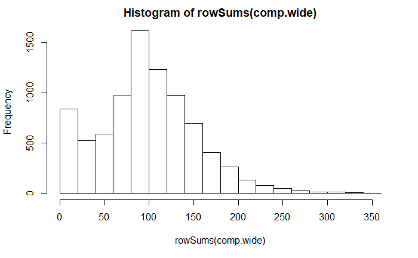

```r
hist(rowSums(comp.wide))
```

**Which plots are responsible for this skewed data?**

Some other values are also really high - why might this be the case? Worth checking with Valerie and David.

```r
wide.comp[order(rowSums(comp.wide), decreasing = TRUE)[1:10],c(1:6, 26:ncol(wide.comp))]
```

```
     plot block subblock       water fertilization year aegilops ag.big ag.small amsinckia avena big.leaf.dandelion
1231  124     2        1         wet          none 2008     12.5      0        0         0  12.5                  0
1221  123     2        1         wet     high fert 2008      0.0      0        0         0  12.5                  0
3398  340     4        1     control          none 2015      2.5      0        0         0  25.0                  0
869    87     1        3     control          none 2016     35.0      0        0         0   2.5                  0
488    49     1        2 control-2nd     high fert 2015      0.0      0        0         0  12.5                  0
2578  258     3        2     control          none 2015      0.0      0        0         0  12.5                  0
7158  716     7        3 control-2nd          none 2015      0.0      0        0         0  12.5                  0
228    23     1        1     latewet          none 2015      0.0      0        0         0   0.0                  0
4238  424     5        1         wet     high fert 2015     12.5      0        0         0  12.5                  0
8028  803     8        2 control-2nd     high fert 2015      0.0      0        0         0  55.0                  0
     bindweed bro.carinatus bro.hordeaceous bro.madritensis bro.diandrus bunchgrass cap.bur centaurea con.arv
1231        0          12.5            12.5               0          0.0          0       0         0       0
1221        0          12.5            12.5               0          0.0          0       0         0       0
3398        0           0.0             0.0               0          0.0          0       0        25       0
```

[output cut: 51 more lines]

```r
sum(c(comp.wide) > 100)
```

[output not shown]

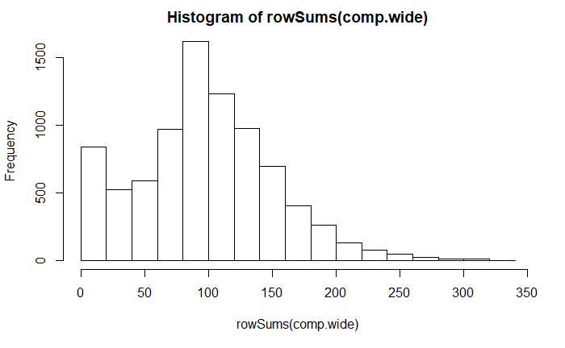

```r
comp.wide[comp.wide == 235] = 23.50
hist(rowSums(comp.wide))
```

```r
wide.comp <- cbind(data.frame(comp.attr), data.frame(comp.wide))
```